# E-commerce Data Analytics

#### Dataset info:

- Sample Dataset Contains the e-commerce Data of Amazon Company . In this project I have done the Exploratory Data Analysis(EDA) on e-commerce Data by using Python(Pandas, Seaborn and Matplotlib).

```python
# import the required libraries

import numpy as np
import pandas as pd
import matplotlib.pyplot as plt
import seaborn as sns
```

#### Load the data file and look at some records of the data

```python
df= pd.read_excel('SALESDATA.xls')
df
```

|  | CustKey | DateKey | Discount Amount | Invoice Date | Invoice Number | Item Class | Item Number | Item | Line Number | List Price | ... | Sales Amount | Sales Amount Based on List Price | Sales Cost Amount | Sales Margin Amount | Sales Price | Sales Quantity | Sales Rep | U/M | Unnamed: 20 | Unnamed: 21 |
| --- | --- | --- | --- | --- | --- | --- | --- | --- | --- | --- | --- | --- | --- | --- | --- | --- | --- | --- | --- | --- | --- |
| 0 | 10000481 | 2017-04-30 | -237.91 | 2017-04-30 | 100012 | NaN | NaN | Urban Large Eggs | 2000 | 0.00 | ... | 237.91 | 0.00 | 0.00 | 237.91 | 237.910000 | 1 | 184 | EA | NaN | U/M = unit of measure |
| 1 | 10002220 | 2017-07-14 | 368.79 | 2017-07-14 | 100233 | P01 | 20910 | Moms Sliced Turkey | 1000 | 824.96 | ... | 456.17 | 824.96 | 0.00 | 456.17 | 456.170000 | 1 | 127 | EA | NaN | NaN |
| 2 | 10002220 | 2017-10-17 | 109.73 | 2017-10-17 | 116165 | P01 | 38076 | Cutting Edge Foot-Long Hot Dogs | 1000 | 548.66 | ... | 438.93 | 548.66 | 0.00 | 438.93 | 438.930000 | 1 | 127 | EA | NaN | EA = each |
| 3 | 10002489 | 2017-06-03 | -211.75 | 2017-06-03 | 100096 | NaN | NaN | Kiwi Lox | 1000 | 0.00 | ... | 211.75 | 0.00 | 0.00 | 211.75 | 211.750000 | 1 | 160 | EA | NaN | NaN |
| 4 | 10004516 | 2017-05-27 | 96627.94 | 2017-05-27 | 103341 | P01 | 60776 | High Top Sweet Onion | 1000 | 408.52 | ... | 89248.66 | 185876.60 | 0.00 | 89248.66 | 196.150901 | 455 | 124 | SE | NaN | SE = some SI unit like kgs or gallons |
| ... | ... | ... | ... | ... | ... | ... | ... | ... | ... | ... | ... | ... | ... | ... | ... | ... | ... | ... | ... | ... | ... |
| 65277 | 10017638 | 2018-03-21 | 505.78 | 2018-03-21 | 226497 | P01 | 13447 | High Top Oranges | 8000 | 119.52 | ... | 569.90 | 1075.68 | 239.95 | 329.95 | 63.322222 | 9 | 180 | EA | NaN | NaN |
| 65278 | 10017638 | 2018-03-21 | 410.75 | 2018-03-21 | 226497 | P01 | 25906 | Landslide White Sugar | 38000 | 436.78 | ... | 462.81 | 873.56 | 423.55 | 39.26 | 231.405000 | 2 | 180 | EA | NaN | NaN |
| 65279 | 10017638 | 2018-03-21 | 876.16 | 2018-03-21 | 226497 | P01 | 61856 | Moms Potato Salad | 227001 | 232.92 | ... | 987.20 | 1863.36 | 574.00 | 413.20 | 123.400000 | 8 | 180 | EA | NaN | NaN |
| 65280 | 10017638 | 2018-03-21 | 24226.77 | 2018-03-21 | 226498 | P01 | 17801 | Better Fancy Canned Sardines | 1000 | 1431.23 | ... | 27297.51 | 51524.28 | 16188.90 | 11108.61 | 758.264167 | 36 | 180 | EA | NaN | NaN |
| 65281 | 10017638 | 2018-03-21 | 24479.26 | 2018-03-21 | 226498 | P01 | 27550 | Imagine Popsicles | 4000 | 1084.61 | ... | 27582.02 | 52061.28 | 14234.22 | 13347.80 | 574.625417 | 48 | 180 | EA | NaN | NaN |

65282 rows × 22 columns

#### Check the various attributes of data like shape(rows and columns),columns,datatypes

```python
df.shape
```

```
(65282, 22)
```

```python
df.columns.values
```

```
array(['CustKey', 'DateKey', 'Discount Amount', 'Invoice Date',
       'Invoice Number', 'Item Class', 'Item Number', 'Item',
       'Line Number', 'List Price', 'Order Number',
       'Promised Delivery Date', 'Sales Amount',
       'Sales Amount Based on List Price', 'Sales Cost Amount',
       'Sales Margin Amount', 'Sales Price', 'Sales Quantity',
       'Sales Rep', 'U/M', 'Unnamed: 20', 'Unnamed: 21'], dtype=object)
```

```python
# Checking the data types of all the columns

df.dtypes
```

```
CustKey                                      int64
DateKey                             datetime64[ns]
Discount Amount                            float64
Invoice Date                        datetime64[ns]
Invoice Number                               int64
Item Class                                  object
Item Number                                 object
Item                                        object
Line Number                                  int64
List Price                                 float64
Order Number                                 int64
Promised Delivery Date              datetime64[ns]
Sales Amount                               float64
Sales Amount Based on List Price           float64
Sales Cost Amount                          float64
Sales Margin Amount                        float64
Sales Price                                float64
Sales Quantity                               int64
Sales Rep                                    int64
U/M                                         object
Unnamed: 20                                float64
Unnamed: 21                                 object
dtype: object
```

- In the above we can see the all the columns having the correct datatypes , but i have a doubt the item number in the above is object datatype so lets check whether the value of this column contains object datatype or the datatype is wrong.
- Before that lets change the name of the columns so that it will be easy to perform all sorts of analysis further.

## Changing the name of the Columns

```python
df.rename({'Discount Amount':'Discount_Amount','Invoice Date':'Invoice_Date','Invoice Number':'Invoice_Number','Item Class':'Item_Class','Item Number':'Item_Number','Line Number':'Line_Number','List Price':'List_Price','Order Number':'Order_Number','Promised Delivery Date':'Promised_Delivery_Date','Sales Amount':'Sales_Amount','Sales Amount Based on List Price':'Sales_Amount_Based_on_List_Price','Sales Cost Amount':'Sales_Cost_Amount','Sales Margin Amount':'Sales_Margin_Amount','Sales Price':'Sales_Price','Sales Quantity':'Sales_Quantity','Sales Rep':'Sales_Rep','Unnamed: 20':'Unnamed:20','Unnamed: 21':'Unnamed:21'},axis=1,inplace=True)
```

```python
# Checking up the unique values

df.Item_Number.unique()
```

```
array([nan, 20910, 38076, 60776, 62550, 60794, 36001, 61484, 17801, 48500,
       38631, 60449, 61801, 63113, 38050, 38007, 28401, 26361, 45880,
       29394, 25300, 26502, 26749, 47801, 37172, 31875, 27550, 47550,
       24336, 64798, 62700, 31682, 29753, 29255, 36015, 39594, 39900,
       63235, 26629, 601700, 62027, 63070, 37609, 37606, 38845, 5742,
       39901, 39680, 604700, 15271, 33446, 30360, 20990, 64672, 35197,
       63680, 38051, 63560, 32720, 37170, 60900, 25870, 37441, 30500,
       62058, 62846, 61762, 24335, 67550, 285002, 275502, 265012, 29071,
       28739, 39681, 28881, 63645, 63664, 39190, 63663, 39906, 26543,
       30092, 11690, 28751, 30285, 61619, 63080, 61465, 62055, 30042,
       34975, 62616, 63559, 7536, 30286, 61855, 39105, 239782, 30093,
       33503, 39185, 61501, 38844, 62871, 33475, 28929, 34581, 60035,
       61930, 38109, 38786, 63650, 37880, 37060, 23426, 36949, 30447,
       35009, 14919, 35112, 31320, 35010, 38826, 64800, 61854, 39116,
       29260, 33245, 34238, 62623, 63744, 15236, 36030, 22680, 32966,
```

[output cut: 108 more lines]

- we can see in the above that the item_number datatype is correct because there are some letters with numbers inside it so no need to change the data types we can move into our further analysis.

# Data Cleaning

- For features with very high number of missing values- it is better to drop those columns as they give very less insight on analysis.
- As there is not any specific rule on what criteria do we delete the columns with high number of missing values, but generally you can delete the columns, if you have more than 30-40% of missing values. but again there is a catch here, for example, Is_Car & Car_Type, people having no cars, will obviously have Car_Type as NaN(null), but that does not make this column useless, so decisions has to be taken Wisely.

```python
df.isnull().sum()
```

```
CustKey                                 0
DateKey                                 0
Discount_Amount                         2
Invoice_Date                            0
Invoice_Number                          0
Item_Class                           8289
Item_Number                            41
Item                                    0
Line_Number                             0
List_Price                              0
Order_Number                            0
Promised_Delivery_Date                  0
Sales_Amount                            0
Sales_Amount_Based_on_List_Price        0
Sales_Cost_Amount                       0
Sales_Margin_Amount                     0
Sales_Price                             1
Sales_Quantity                          0
Sales_Rep                               0
U/M                                     0
Unnamed:20                          65282
Unnamed:21                          65278
dtype: int64
```

- As we can see there are 65282 in Unnamed:20 column and Unnamed:21 column contains 65278 null values so the number of nulls inside these two columns is almost equal to the shape of the dataframe so it is better to drop those two columns as it is not giving any insights.

# Missing Value Treatement

### * As we can see there are 65282 in Unnamed:20 column and Unnamed:21 column contains 65278 null values so the number of nulls inside these two columns is almost equal to the shape of the dataframe so it is better to drop those two columns as it is not giving any insights.

```python
# checking number of nulls

df['Unnamed:20'].value_counts(dropna=False)
```

```
NaN    65282
Name: Unnamed:20, dtype: int64
```

```python
# Droping the column

df.drop('Unnamed:20',axis=1,inplace=True)

df.head()
```

|  | CustKey | DateKey | Discount_Amount | Invoice_Date | Invoice_Number | Item_Class | Item_Number | Item | Line_Number | List_Price | ... | Promised_Delivery_Date | Sales_Amount | Sales_Amount_Based_on_List_Price | Sales_Cost_Amount | Sales_Margin_Amount | Sales_Price | Sales_Quantity | Sales_Rep | U/M | Unnamed:21 |
| --- | --- | --- | --- | --- | --- | --- | --- | --- | --- | --- | --- | --- | --- | --- | --- | --- | --- | --- | --- | --- | --- |
| 0 | 10000481 | 2017-04-30 | -237.91 | 2017-04-30 | 100012 | NaN | NaN | Urban Large Eggs | 2000 | 0.00 | ... | 2017-04-30 | 237.91 | 0.00 | 0.0 | 237.91 | 237.910000 | 1 | 184 | EA | U/M = unit of measure |
| 1 | 10002220 | 2017-07-14 | 368.79 | 2017-07-14 | 100233 | P01 | 20910 | Moms Sliced Turkey | 1000 | 824.96 | ... | 2017-07-14 | 456.17 | 824.96 | 0.0 | 456.17 | 456.170000 | 1 | 127 | EA | NaN |
| 2 | 10002220 | 2017-10-17 | 109.73 | 2017-10-17 | 116165 | P01 | 38076 | Cutting Edge Foot-Long Hot Dogs | 1000 | 548.66 | ... | 2017-10-16 | 438.93 | 548.66 | 0.0 | 438.93 | 438.930000 | 1 | 127 | EA | EA = each |
| 3 | 10002489 | 2017-06-03 | -211.75 | 2017-06-03 | 100096 | NaN | NaN | Kiwi Lox | 1000 | 0.00 | ... | 2017-06-03 | 211.75 | 0.00 | 0.0 | 211.75 | 211.750000 | 1 | 160 | EA | NaN |
| 4 | 10004516 | 2017-05-27 | 96627.94 | 2017-05-27 | 103341 | P01 | 60776 | High Top Sweet Onion | 1000 | 408.52 | ... | 2017-05-28 | 89248.66 | 185876.60 | 0.0 | 89248.66 | 196.150901 | 455 | 124 | SE | SE = some SI unit like kgs or gallons |

5 rows × 21 columns

```python
# checking number of nulls

df['Unnamed:21'].value_counts(dropna=False)
```

```
NaN                                      65278
U/M = unit of measure                        1
PR = pair                                    1
SE = some SI unit like kgs or gallons        1
EA = each                                    1
Name: Unnamed:21, dtype: int64
```

```python
# Droping the column

df.drop('Unnamed:21',axis=1,inplace=True)

# Looking at the top 5 records of the data

df.head()
```

|  | CustKey | DateKey | Discount_Amount | Invoice_Date | Invoice_Number | Item_Class | Item_Number | Item | Line_Number | List_Price | Order_Number | Promised_Delivery_Date | Sales_Amount | Sales_Amount_Based_on_List_Price | Sales_Cost_Amount | Sales_Margin_Amount | Sales_Price | Sales_Quantity | Sales_Rep | U/M |
| --- | --- | --- | --- | --- | --- | --- | --- | --- | --- | --- | --- | --- | --- | --- | --- | --- | --- | --- | --- | --- |
| 0 | 10000481 | 2017-04-30 | -237.91 | 2017-04-30 | 100012 | NaN | NaN | Urban Large Eggs | 2000 | 0.00 | 200015 | 2017-04-30 | 237.91 | 0.00 | 0.0 | 237.91 | 237.910000 | 1 | 184 | EA |
| 1 | 10002220 | 2017-07-14 | 368.79 | 2017-07-14 | 100233 | P01 | 20910 | Moms Sliced Turkey | 1000 | 824.96 | 200245 | 2017-07-14 | 456.17 | 824.96 | 0.0 | 456.17 | 456.170000 | 1 | 127 | EA |
| 2 | 10002220 | 2017-10-17 | 109.73 | 2017-10-17 | 116165 | P01 | 38076 | Cutting Edge Foot-Long Hot Dogs | 1000 | 548.66 | 213157 | 2017-10-16 | 438.93 | 548.66 | 0.0 | 438.93 | 438.930000 | 1 | 127 | EA |
| 3 | 10002489 | 2017-06-03 | -211.75 | 2017-06-03 | 100096 | NaN | NaN | Kiwi Lox | 1000 | 0.00 | 200107 | 2017-06-03 | 211.75 | 0.00 | 0.0 | 211.75 | 211.750000 | 1 | 160 | EA |
| 4 | 10004516 | 2017-05-27 | 96627.94 | 2017-05-27 | 103341 | P01 | 60776 | High Top Sweet Onion | 1000 | 408.52 | 203785 | 2017-05-28 | 89248.66 | 185876.60 | 0.0 | 89248.66 | 196.150901 | 455 | 124 | SE |

- After the Droping of above two columns lets remove missing values of all other columns below.

```python
df.isnull().sum()
```

```
CustKey                                0
DateKey                                0
Discount_Amount                        2
Invoice_Date                           0
Invoice_Number                         0
Item_Class                          8289
Item_Number                           41
Item                                   0
Line_Number                            0
List_Price                             0
Order_Number                           0
Promised_Delivery_Date                 0
Sales_Amount                           0
Sales_Amount_Based_on_List_Price       0
Sales_Cost_Amount                      0
Sales_Margin_Amount                    0
Sales_Price                            1
Sales_Quantity                         0
Sales_Rep                              0
U/M                                    0
dtype: int64
```

```python
# Removing missing values

df.dropna(subset=['Item_Class'],how='any',inplace=True)
df.shape
```

```
(56993, 20)
```

```python
df.isnull().sum()
```

```
CustKey                             0
DateKey                             0
Discount_Amount                     0
Invoice_Date                        0
Invoice_Number                      0
Item_Class                          0
Item_Number                         0
Item                                0
Line_Number                         0
List_Price                          0
Order_Number                        0
Promised_Delivery_Date              0
Sales_Amount                        0
Sales_Amount_Based_on_List_Price    0
Sales_Cost_Amount                   0
Sales_Margin_Amount                 0
Sales_Price                         0
Sales_Quantity                      0
Sales_Rep                           0
U/M                                 0
dtype: int64
```

- Now we can see there are not any more missing values present inside the dataset.

```python
# Checking about duplicated values

df.duplicated().sum()
```

```
0
```

```python
df.shape
```

```
(56993, 20)
```

### Checking the Descriptive Statistics of numeric variables

```python
df.describe()
```

|  | CustKey | Discount_Amount | Invoice_Number | Line_Number | List_Price | Order_Number | Sales_Amount | Sales_Amount_Based_on_List_Price | Sales_Cost_Amount | Sales_Margin_Amount | Sales_Price | Sales_Quantity | Sales_Rep |
| --- | --- | --- | --- | --- | --- | --- | --- | --- | --- | --- | --- | --- | --- |
| count | 5.699300e+04 | 56993.000000 | 56993.000000 | 56993.000000 | 56993.000000 | 56993.000000 | 56993.000000 | 56993.000000 | 56993.000000 | 56993.000000 | 56993.000000 | 56993.000000 | 56993.00000 |
| mean | 1.001758e+07 | 1526.396318 | 216407.511537 | 24588.751777 | 536.262010 | 180463.928675 | 1655.777031 | 3182.173348 | 925.933614 | 729.843417 | 290.313444 | 9.841472 | 136.69312 |
| std | 7.231012e+03 | 5327.696464 | 95002.543962 | 32477.174741 | 446.072796 | 67594.415280 | 5309.497134 | 10546.977037 | 3169.623938 | 2328.875603 | 244.347560 | 34.132815 | 26.47562 |
| min | 1.000045e+07 | -15030.790000 | 100034.000000 | 1000.000000 | 0.000000 | 100838.000000 | 200.010000 | 0.000000 | 0.000000 | -717.590000 | 1.282816 | 1.000000 | 103.00000 |
| 25% | 1.001242e+07 | 255.950000 | 117962.000000 | 4000.000000 | 190.850000 | 115223.000000 | 301.460000 | 561.040000 | 162.890000 | 128.520000 | 102.403333 | 2.000000 | 113.00000 |
| 50% | 1.001940e+07 | 455.900000 | 222954.000000 | 13000.000000 | 378.290000 | 203670.000000 | 533.640000 | 983.440000 | 295.240000 | 237.940000 | 202.910000 | 3.000000 | 130.00000 |
| 75% | 1.002351e+07 | 1006.424400 | 314275.000000 | 33000.000000 | 824.962500 | 218640.000000 | 1170.680000 | 2169.220000 | 626.900000 | 524.720000 | 463.920000 | 6.000000 | 160.00000 |
| max | 1.002758e+07 | 191196.553200 | 332842.000000 | 330000.000000 | 1975.000000 | 321532.000000 | 215364.600000 | 391924.723200 | 118903.530000 | 96461.070000 | 1474.170000 | 1000.000000 | 185.00000 |

```python
# Concise Summary of the dataframe

df.info()
```

```
<class 'pandas.core.frame.DataFrame'>
Int64Index: 56993 entries, 1 to 65281
Data columns (total 20 columns):
 #   Column                            Non-Null Count  Dtype
---  ------                            --------------  -----
 0   CustKey                           56993 non-null  int64
 1   DateKey                           56993 non-null  datetime64[ns]
 2   Discount_Amount                   56993 non-null  float64
 3   Invoice_Date                      56993 non-null  datetime64[ns]
 4   Invoice_Number                    56993 non-null  int64
 5   Item_Class                        56993 non-null  object
 6   Item_Number                       56993 non-null  object
 7   Item                              56993 non-null  object
 8   Line_Number                       56993 non-null  int64
 9   List_Price                        56993 non-null  float64
 10  Order_Number                      56993 non-null  int64
 11  Promised_Delivery_Date            56993 non-null  datetime64[ns]
 12  Sales_Amount                      56993 non-null  float64
 13  Sales_Amount_Based_on_List_Price  56993 non-null  float64
 14  Sales_Cost_Amount                 56993 non-null  float64
 15  Sales_Margin_Amount               56993 non-null  float64
 16  Sales_Price                       56993 non-null  float64
 17  Sales_Quantity                    56993 non-null  int64
 18  Sales_Rep                         56993 non-null  int64
 19  U/M                               56993 non-null  object
dtypes: datetime64[ns](3), float64(7), int64(6), object(4)
memory usage: 9.1+ MB
```

# Data Exploration

### Bivariate Analysis

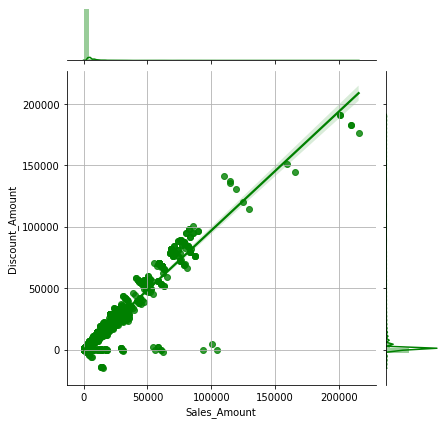

```python
# Relationship between sales amount vs discount amount

plt.figure(figsize=(6,5))

sns.jointplot(x='Sales_Amount',y='Discount_Amount',data=df,kind='reg',color='green')

plt.grid()

plt.show()
```

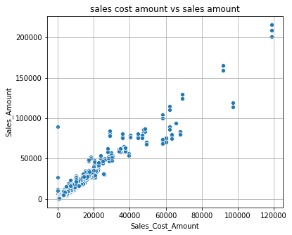

```python
# Relationship between sales cost amount vs sales amount

plt.figure(figsize=(6,5))

sns.scatterplot(x='Sales_Cost_Amount',y='Sales_Amount',data=df)

plt.title('sales cost amount vs sales amount')
plt.grid()
plt.show()
```

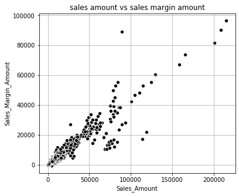

```python
# Correlation between sales amount vs sales margin amount

plt.figure(figsize=(6,5))

sns.scatterplot(x='Sales_Amount',y='Sales_Margin_Amount',data=df, color='black')

plt.title('sales amount vs sales margin amount')

plt.grid()
plt.show()
```

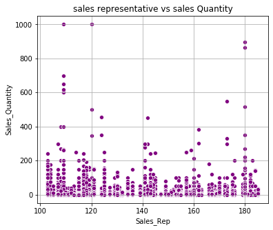

```python
# Correlation between sales representative vs sales quantity

plt.figure(figsize=(6,5))

sns.scatterplot(x='Sales_Rep',y='Sales_Quantity',data=df, color='purple')

plt.title('sales representative vs sales Quantity')

plt.grid()
plt.show()
```

## Multivariate analysis

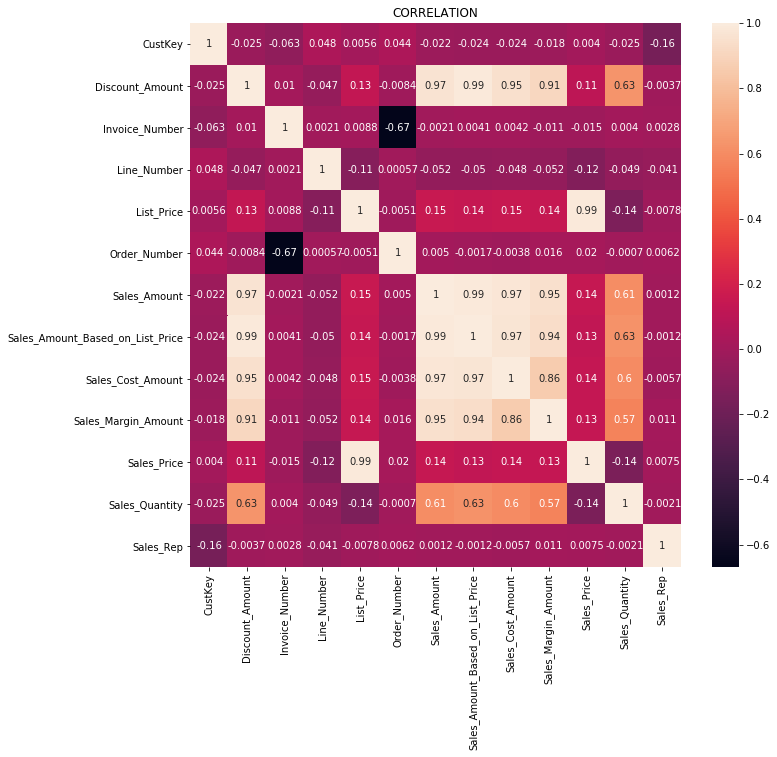

```python
plt.figure(figsize=(11,10))
sns.heatmap(df.corr(), annot= True)
plt.title('CORRELATION')
```

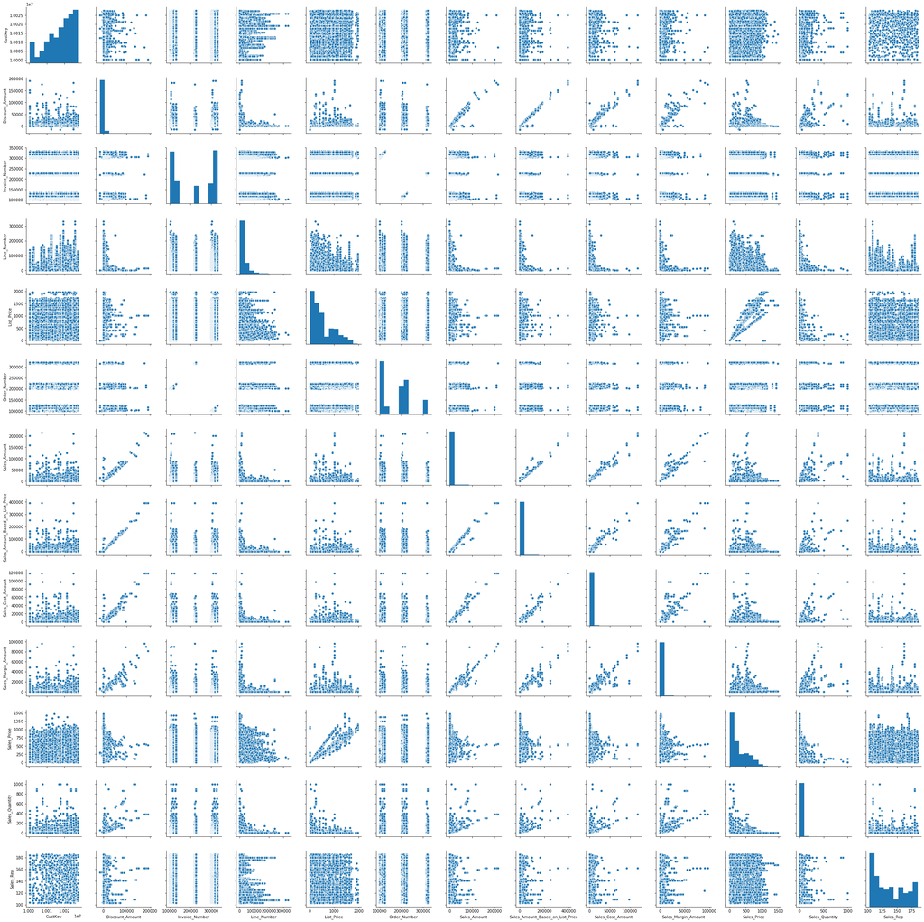

```python
sns.pairplot(df)
```

# Top 10 most selling Items by Sales_Amount

```python
## grouping Item name column by using group by method-

item_sales=pd.DataFrame(df.groupby('Item').sum()['Sales_Amount'])
item_sales
```

| Item | Sales_Amount |
| --- | --- |
| American Beef Bologna | 2730.18 |
| American Chicken Hot Dogs | 8904.65 |
| American Corned Beef | 1283.36 |
| American Pimento Loaf | 48739.53 |
| American Potato Salad | 45159.32 |
| ... | ... |
| Washington Cranberry Juice | 51131.98 |
| Washington Cream Soda | 60736.79 |
| Washington Diet Cola | 10926.01 |
| Washington Diet Soda | 359798.84 |
| Washington Mango Drink | 52309.90 |

479 rows × 1 columns

```python
## sorting Item Sales_Amount column-

items_sales= item_sales.sort_values('Sales_Amount',ascending=False)
items_sales
```

| Item | Sales_Amount |
| --- | --- |
| Ebony Squash | 5377848.64 |
| Big Time Frozen Cheese Pizza | 5127171.17 |
| Discover Manicotti | 4901139.48 |
| Better Fancy Canned Sardines | 4526698.89 |
| Moms Sliced Turkey | 3386948.16 |
| ... | ... |
| Imagine Grape Popsicles | 205.32 |
| Kiwi Lox | 204.71 |
| Just Right Rice Soup | 202.46 |
| Ebony Mixed Nuts | 201.16 |
| Nationeel BBQ Potato Chips | 200.55 |

479 rows × 1 columns

## Top 10 most selling items by Sales_Amount below

```python
items_sales[:10]
```

| Item | Sales_Amount |
| --- | --- |
| Ebony Squash | 5377848.64 |
| Big Time Frozen Cheese Pizza | 5127171.17 |
| Discover Manicotti | 4901139.48 |
| Better Fancy Canned Sardines | 4526698.89 |
| Moms Sliced Turkey | 3386948.16 |
| Imagine Popsicles | 3347066.54 |
| Cutting Edge Foot-Long Hot Dogs | 3340837.52 |
| Ebony Prepared Salad | 2793741.24 |
| Big Time Frozen Peas | 2784626.53 |
| Walrus White Zinfandel Wine | 2678643.25 |

[figure not shown]

```python
labels='Better Large Canned Shrimp','High Top Dried Mushrooms','Red Spade Pimento Loaf','Better Canned Tuna in Oil','Ebony Squash'
sizes=[15454172.47,13368414.53,5711486.45,5693075.12,5380727.75]
colors=['gold','yellowgreen','lightcoral','lightskyblue','red']
explode=(0.1,0,0,0,0)

plt.pie(sizes,explode=explode,labels=labels, colors=colors,
autopct= '%1.1f%%', shadow= True)

plt.axis('equal')
plt.show()
```

# Bottom 10 most selling Items by Sales_Amount

```python
## grouping Item name column by using group by method-

Item_sales=pd.DataFrame(df.groupby('Item').sum()['Sales_Amount'])
Item_sales
```

| Item | Sales_Amount |
| --- | --- |
| American Beef Bologna | 2730.18 |
| American Chicken Hot Dogs | 8904.65 |
| American Corned Beef | 1283.36 |
| American Pimento Loaf | 48739.53 |
| American Potato Salad | 45159.32 |
| ... | ... |
| Washington Cranberry Juice | 51131.98 |
| Washington Cream Soda | 60736.79 |
| Washington Diet Cola | 10926.01 |
| Washington Diet Soda | 359798.84 |
| Washington Mango Drink | 52309.90 |

479 rows × 1 columns

```python
## sorting Item Sales_Amount column-

Items_sales= item_sales.sort_values('Sales_Amount',ascending=True)
Items_sales
```

| Item | Sales_Amount |
| --- | --- |
| Nationeel BBQ Potato Chips | 200.55 |
| Ebony Mixed Nuts | 201.16 |
| Just Right Rice Soup | 202.46 |
| Kiwi Lox | 204.71 |
| Imagine Grape Popsicles | 205.32 |
| ... | ... |
| Moms Sliced Turkey | 3386948.16 |
| Better Fancy Canned Sardines | 4526698.89 |
| Discover Manicotti | 4901139.48 |
| Big Time Frozen Cheese Pizza | 5127171.17 |
| Ebony Squash | 5377848.64 |

479 rows × 1 columns

```python
Items_sales[:10]
```

| Item | Sales_Amount |
| --- | --- |
| Nationeel BBQ Potato Chips | 200.55 |
| Ebony Mixed Nuts | 201.16 |
| Just Right Rice Soup | 202.46 |
| Kiwi Lox | 204.71 |
| Imagine Grape Popsicles | 205.32 |
| Best Choice Sesame Crackers | 206.98 |
| Best Choice Beef Jerky | 406.40 |
| Fast Graham Crackers | 435.53 |
| Moms Foot-Long Hot Dogs | 441.63 |
| Best Choice Dried Apricots | 470.01 |

# Top 10 Items by Sales_Margin_Amount (profit)

```python
## grouping Item name column by using group by method-

item_sales=pd.DataFrame(df.groupby('Item').sum()['Sales_Margin_Amount'])
item_sales
```

| Item | Sales_Margin_Amount |
| --- | --- |
| American Beef Bologna | 840.04 |
| American Chicken Hot Dogs | 5981.63 |
| American Corned Beef | 716.92 |
| American Pimento Loaf | 37537.93 |
| American Potato Salad | 4809.75 |
| ... | ... |
| Washington Cranberry Juice | 27202.82 |
| Washington Cream Soda | 6319.60 |
| Washington Diet Cola | 8106.40 |
| Washington Diet Soda | 119333.92 |
| Washington Mango Drink | 5639.67 |

479 rows × 1 columns

```python
## sorting Item Sales_Margin_Amount column-

items_sales= item_sales.sort_values('Sales_Margin_Amount',ascending=False)
items_sales
```

| Item | Sales_Margin_Amount |
| --- | --- |
| Big Time Frozen Cheese Pizza | 2826772.99 |
| Discover Manicotti | 2381667.84 |
| Ebony Squash | 2335451.73 |
| Better Fancy Canned Sardines | 1882049.45 |
| Cutting Edge Foot-Long Hot Dogs | 1821239.29 |
| ... | ... |
| Carlson Strawberry Yogurt | -30.42 |
| Carlson Chocolate Milk | -69.84 |
| Carlson Head Cheese | -334.57 |
| Carlson Sharp Cheddar Cheese | -800.92 |
| Carlson Mild Cheddar Cheese | -908.45 |

479 rows × 1 columns

## Top 10 Items by Sales_Margin_Amount (profit) below

```python
items_sales[:10]
```

| Item | Sales_Margin_Amount |
| --- | --- |
| Big Time Frozen Cheese Pizza | 2826772.99 |
| Discover Manicotti | 2381667.84 |
| Ebony Squash | 2335451.73 |
| Better Fancy Canned Sardines | 1882049.45 |
| Cutting Edge Foot-Long Hot Dogs | 1821239.29 |
| Imagine Popsicles | 1591326.99 |
| Moms Sliced Turkey | 1385972.90 |
| Ebony Prepared Salad | 1316365.81 |
| Red Spade Turkey Hot Dogs | 1197816.76 |
| Golden Frozen Corn | 1196271.33 |

# Bottom 10 Items by Sales_Margin_Amount (profit)

```python
## grouping Item name column by using group by method-

Item_sales=pd.DataFrame(df.groupby('Item').sum()['Sales_Margin_Amount'])
Item_sales
```

| Item | Sales_Margin_Amount |
| --- | --- |
| American Beef Bologna | 840.04 |
| American Chicken Hot Dogs | 5981.63 |
| American Corned Beef | 716.92 |
| American Pimento Loaf | 37537.93 |
| American Potato Salad | 4809.75 |
| ... | ... |
| Washington Cranberry Juice | 27202.82 |
| Washington Cream Soda | 6319.60 |
| Washington Diet Cola | 8106.40 |
| Washington Diet Soda | 119333.92 |
| Washington Mango Drink | 5639.67 |

479 rows × 1 columns

```python
## sorting Item Sales_Margin_Amount column-

Items_sales= item_sales.sort_values('Sales_Margin_Amount',ascending=True)
Items_sales
```

| Item | Sales_Margin_Amount |
| --- | --- |
| Carlson Mild Cheddar Cheese | -908.45 |
| Carlson Sharp Cheddar Cheese | -800.92 |
| Carlson Head Cheese | -334.57 |
| Carlson Chocolate Milk | -69.84 |
| Carlson Strawberry Yogurt | -30.42 |
| ... | ... |
| Cutting Edge Foot-Long Hot Dogs | 1821239.29 |
| Better Fancy Canned Sardines | 1882049.45 |
| Ebony Squash | 2335451.73 |
| Discover Manicotti | 2381667.84 |
| Big Time Frozen Cheese Pizza | 2826772.99 |

479 rows × 1 columns

```python
Items_sales[:10]
```

| Item | Sales_Margin_Amount |
| --- | --- |
| Carlson Mild Cheddar Cheese | -908.45 |
| Carlson Sharp Cheddar Cheese | -800.92 |
| Carlson Head Cheese | -334.57 |
| Carlson Chocolate Milk | -69.84 |
| Carlson Strawberry Yogurt | -30.42 |
| Kiwi Lox | 46.39 |
| Landslide Low Fat Apple Butter | 48.68 |
| Ebony Mixed Nuts | 58.25 |
| Just Right Rice Soup | 75.64 |
| Imagine Grape Popsicles | 78.53 |

# Top 10 Items by Discount_Amount

```python
## grouping Item name column by using group by method-

dis_amount=pd.DataFrame(df.groupby('Item').sum()['Discount_Amount'])
dis_amount
```

| Item | Discount_Amount |
| --- | --- |
| American Beef Bologna | 3052.02 |
| American Chicken Hot Dogs | 8010.35 |
| American Corned Beef | 990.24 |
| American Pimento Loaf | 44437.47 |
| American Potato Salad | 47264.28 |
| ... | ... |
| Washington Cranberry Juice | 42747.04 |
| Washington Cream Soda | 62240.91 |
| Washington Diet Cola | 3689.53 |
| Washington Diet Soda | 326406.16 |
| Washington Mango Drink | 54286.94 |

479 rows × 1 columns

```python
## sorting Item Discount_Amount column-

dis_amounts= dis_amount.sort_values('Discount_Amount',ascending=False)
dis_amounts
```

| Item | Discount_Amount |
| --- | --- |
| Big Time Frozen Cheese Pizza | 5.978925e+06 |
| Ebony Squash | 4.582161e+06 |
| Discover Manicotti | 4.315283e+06 |
| Better Fancy Canned Sardines | 3.869920e+06 |
| Big Time Frozen Peas | 3.155172e+06 |
| ... | ... |
| Nationeel Fondue Mix | 1.869000e+01 |
| Nationeel Dried Apricots | 1.869000e+01 |
| Nationeel Cheese Dip | 1.869000e+01 |
| Thresher Tasty Candy Bar | 1.869000e+01 |
| Even Better Havarti Cheese | -1.125120e+05 |

479 rows × 1 columns

## Top 10 Items by Discount_Amount below

```python
dis_amounts[:10]
```

| Item | Discount_Amount |
| --- | --- |
| Big Time Frozen Cheese Pizza | 5.978925e+06 |
| Ebony Squash | 4.582161e+06 |
| Discover Manicotti | 4.315283e+06 |
| Better Fancy Canned Sardines | 3.869920e+06 |
| Big Time Frozen Peas | 3.155172e+06 |
| Cutting Edge Foot-Long Hot Dogs | 3.046441e+06 |
| Walrus White Zinfandel Wine | 3.029015e+06 |
| Imagine Popsicles | 2.974242e+06 |
| Moms Sliced Turkey | 2.902835e+06 |
| Ebony Prepared Salad | 2.388721e+06 |

# Bottom 10 Items by Discount_Amount

```python
## grouping Item name column by using group by method-

dis_amount=pd.DataFrame(df.groupby('Item').sum()['Discount_Amount'])
dis_amount
```

| Item | Discount_Amount |
| --- | --- |
| American Beef Bologna | 3052.02 |
| American Chicken Hot Dogs | 8010.35 |
| American Corned Beef | 990.24 |
| American Pimento Loaf | 44437.47 |
| American Potato Salad | 47264.28 |
| ... | ... |
| Washington Cranberry Juice | 42747.04 |
| Washington Cream Soda | 62240.91 |
| Washington Diet Cola | 3689.53 |
| Washington Diet Soda | 326406.16 |
| Washington Mango Drink | 54286.94 |

479 rows × 1 columns

```python
## sorting Item Discount_Amount column-

dis_amounts= dis_amount.sort_values('Discount_Amount',ascending=True)
dis_amounts
```

| Item | Discount_Amount |
| --- | --- |
| Even Better Havarti Cheese | -1.125120e+05 |
| Nationeel Fondue Mix | 1.869000e+01 |
| Nationeel Cheese Dip | 1.869000e+01 |
| Thresher Tasty Candy Bar | 1.869000e+01 |
| Nationeel Dried Apricots | 1.869000e+01 |
| ... | ... |
| Big Time Frozen Peas | 3.155172e+06 |
| Better Fancy Canned Sardines | 3.869920e+06 |
| Discover Manicotti | 4.315283e+06 |
| Ebony Squash | 4.582161e+06 |
| Big Time Frozen Cheese Pizza | 5.978925e+06 |

479 rows × 1 columns

```python
dis_amounts[:10]
```

| Item | Discount_Amount |
| --- | --- |
| Even Better Havarti Cheese | -112512.0300 |
| Nationeel Fondue Mix | 18.6900 |
| Nationeel Cheese Dip | 18.6900 |
| Thresher Tasty Candy Bar | 18.6900 |
| Nationeel Dried Apricots | 18.6900 |
| Club Low Fat Cottage Cheese | 21.2500 |
| Radius Oatmeal | 63.7800 |
| Big Time Frozen Cauliflower | 84.8000 |
| Just Right Rice Soup | 156.7525 |
| Kiwi Lox | 170.2900 |

# Top 10 Items by Sales_Cost_Amount

```python
## grouping Item name column by using group by method-

Sales_cost =pd.DataFrame(df.groupby('Item').sum()['Sales_Cost_Amount'])
Sales_cost
```

| Item | Sales_Cost_Amount |
| --- | --- |
| American Beef Bologna | 1890.14 |
| American Chicken Hot Dogs | 2923.02 |
| American Corned Beef | 566.44 |
| American Pimento Loaf | 11201.60 |
| American Potato Salad | 40349.57 |
| ... | ... |
| Washington Cranberry Juice | 23929.16 |
| Washington Cream Soda | 54417.19 |
| Washington Diet Cola | 2819.61 |
| Washington Diet Soda | 240464.92 |
| Washington Mango Drink | 46670.23 |

479 rows × 1 columns

```python
## sorting Item sales_cost_amount column-

Sales_costs= Sales_cost.sort_values('Sales_Cost_Amount',ascending=False)
Sales_costs
```

| Item | Sales_Cost_Amount |
| --- | --- |
| Ebony Squash | 3042396.91 |
| Better Fancy Canned Sardines | 2644649.44 |
| Discover Manicotti | 2519471.64 |
| Big Time Frozen Cheese Pizza | 2300398.18 |
| Walrus White Zinfandel Wine | 2213924.70 |
| ... | ... |
| Just Right Rice Soup | 126.82 |
| Imagine Grape Popsicles | 126.79 |
| Best Choice Sesame Crackers | 126.68 |
| Nationeel BBQ Potato Chips | 91.53 |
| Colony Muffins | 0.00 |

479 rows × 1 columns

```python
Sales_costs[:10]
```

| Item | Sales_Cost_Amount |
| --- | --- |
| Ebony Squash | 3042396.91 |
| Better Fancy Canned Sardines | 2644649.44 |
| Discover Manicotti | 2519471.64 |
| Big Time Frozen Cheese Pizza | 2300398.18 |
| Walrus White Zinfandel Wine | 2213924.70 |
| Moms Sliced Turkey | 2000975.26 |
| Imagine Popsicles | 1755739.55 |
| Big Time Frozen Peas | 1673780.38 |
| Cutting Edge Foot-Long Hot Dogs | 1519598.23 |
| Ebony Prepared Salad | 1477375.43 |

# Bottom 10 Items by Sales_Cost_Amount

```python
## grouping Item name column by using group by method-

Sales_cost =pd.DataFrame(df.groupby('Item').sum()['Sales_Cost_Amount'])
Sales_cost
```

| Item | Sales_Cost_Amount |
| --- | --- |
| American Beef Bologna | 1890.14 |
| American Chicken Hot Dogs | 2923.02 |
| American Corned Beef | 566.44 |
| American Pimento Loaf | 11201.60 |
| American Potato Salad | 40349.57 |
| ... | ... |
| Washington Cranberry Juice | 23929.16 |
| Washington Cream Soda | 54417.19 |
| Washington Diet Cola | 2819.61 |
| Washington Diet Soda | 240464.92 |
| Washington Mango Drink | 46670.23 |

479 rows × 1 columns

```python
## sorting Item sales_cost_amount column-

Sales_costs= Sales_cost.sort_values('Sales_Cost_Amount',ascending=True)
Sales_costs
```

| Item | Sales_Cost_Amount |
| --- | --- |
| Colony Muffins | 0.00 |
| Nationeel BBQ Potato Chips | 91.53 |
| Best Choice Sesame Crackers | 126.68 |
| Imagine Grape Popsicles | 126.79 |
| Just Right Rice Soup | 126.82 |
| ... | ... |
| Walrus White Zinfandel Wine | 2213924.70 |
| Big Time Frozen Cheese Pizza | 2300398.18 |
| Discover Manicotti | 2519471.64 |
| Better Fancy Canned Sardines | 2644649.44 |
| Ebony Squash | 3042396.91 |

479 rows × 1 columns

```python
Sales_costs[:10]
```

| Item | Sales_Cost_Amount |
| --- | --- |
| Colony Muffins | 0.00 |
| Nationeel BBQ Potato Chips | 91.53 |
| Best Choice Sesame Crackers | 126.68 |
| Imagine Grape Popsicles | 126.79 |
| Just Right Rice Soup | 126.82 |
| Ebony Mixed Nuts | 142.91 |
| Excellent Cranberry Juice | 152.00 |
| Fast Graham Crackers | 154.82 |
| Kiwi Lox | 158.32 |
| Moms Foot-Long Hot Dogs | 167.66 |

- In the above it is showing that the lowest sales cost amount is for Colony Muffins item is 0 so in general we know that the sales cost amount can't be 0 but if such case happens we can consider the sales amount as the sales cost amount for that item .
- so to know the sales amount of Colony Muffins item lets found by using the below used method.

```python
df.loc[df.Item=='Colony Muffins']
```

|  | CustKey | DateKey | Discount_Amount | Invoice_Date | Invoice_Number | Item_Class | Item_Number | Item | Line_Number | List_Price | Order_Number | Promised_Delivery_Date | Sales_Amount | Sales_Amount_Based_on_List_Price | Sales_Cost_Amount | Sales_Margin_Amount | Sales_Price | Sales_Quantity | Sales_Rep | U/M |
| --- | --- | --- | --- | --- | --- | --- | --- | --- | --- | --- | --- | --- | --- | --- | --- | --- | --- | --- | --- | --- |
| 20999 | 10021977 | 2017-05-22 | 277.82 | 2017-05-22 | 102990 | P01 | 37604 | Colony Muffins | 127000 | 306.78 | 203422 | 2017-05-22 | 335.74 | 613.56 | 0.0 | 335.74 | 167.870 | 2 | 117 | EA |
| 22858 | 10021668 | 2019-06-03 | 291.25 | 2019-06-03 | 302990 | P01 | 37604 | Colony Muffins | 127000 | 306.78 | 103422 | 2019-06-03 | 322.31 | 613.56 | 0.0 | 322.31 | 161.155 | 2 | 117 | EA |

- In the above we can see there are two records showing for Colony Muffins item and also those two records sales cost amount shows zero so we can sum those two records sales amount for to get the original value below.

```python
df.loc[df.Item=='Colony Muffins',['Sales_Amount']].sum()
```

```
Sales_Amount    658.05
dtype: float64
```

# Insights :

- There is positive relationship between Sales_Amount and Discount_amount , we can see the Discount_amount increase as Sales_amount increase.
- Between Sales_cost_amount and Sales_amount there is positive relationship we can see sales_amount increases as sales_cost_amount increase.
- There is positive Correlation between Sales_Amount and Sales_margin_amount , we can see the Sales_margin_amount increase as Sales_amount increase which is quite obvious.
- Between Sales_Rep and Sales_Quantity there is no relationship.
- 'Ebony Squash' is having the highest Sales_Amount that is 5377848.64 among the all other items and 'Nationeel BBQ Potato Chips' is having the lowest Sales_amount that is 200.55 among all other items.
- The'Big Time Frozen Cheese Pizza' item is having the maximum sales_margin_amount(profit) that is 2826772.99 and 'Carlson Mild Cheddar Cheese' item is having the lowest profit that is -908.45.
- 'Big Time Frozen Cheese Pizza' item is Contains the highest Discount_amount that is 5978925 and 'Even Better Havarti Cheese' item Contains the lowest discount_amount that is -112512.0300.
- The Item 'Ebony Squash' is having the highest Sales_cost_amount that is 3042396.91.